# Data Visualization

Quan Gan, Yuxuan chen

11/3/2021

# Data Visualization

```r
# load libraries
library(tidyverse)
library(knitr)
```

```r
# load data in
LCA_application <- read_csv("Data/LCA_cleaned.csv")
```

## Question 1

> Question: What companies have high expectations of international workers arcoss years?

In the data set, the employer_name variable is the name of company. We need to figure what companies have more LCA application from 2016 to 2020.

```r
# Find the top 10 companies that have most LCA applications.
LCA_application %>%
  select(employer_name) %>%
  add_count(employer_name) %>%
  arrange(desc(n)) %>%
  unique() %>%
  top_n(10) -> top_10_company
```

```r
# Count the LCA applications of top 10 companies across years
LCA_application %>%
  filter(employer_name %in% top_10_company$employer_name) %>%
  select(employer_name, year) %>%
  group_by(year) %>%
  add_count(employer_name) %>%
  arrange(year, desc(n)) %>%
  unique() -> company_application_number
```

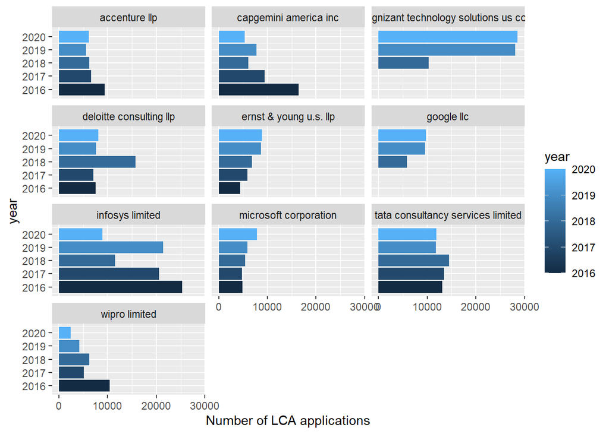

```r
company_application_number %>%
  group_by(employer_name, year) %>%
  ggplot(aes(x = year,
             y = n,
             fill = year)) +
  geom_col(position = "dodge") +
  facet_wrap(~employer_name, ncol = 3) +
  coord_flip() +
  labs(y = "Number of LCA applications")
```

This plot shows the top 10 companies in total that apply for LCA applications from 2016 to 2020. Each subplot shows their applications trends. We could know for Google LLC and cognizant technology solutions us corp, they don’t have LCA applications in 2016 and 2017. Half of top 10 companies increase their LCA applications. In addition, I choose the top 10 companies that have most LCA applications in total rather than choosing each year top 10 companies because some companies might only desire foreign workers in a specific year and analyzing overall top 10 companies could illustrate the recruiting trends.